# Introduction to Python

# Numpy example: Heart Rate

[figure not shown]

https://my.clevelandclinic.org/health/diagnostics/16953-electrocardiogram-ekg

**Example**: suppose we are in a hospital setting. We are programming an *electrocardiogram* device, that is a device which measures the electrical activity near the heart at a rate of 360Hz.

[figure not shown]

https://www.onlinebiologynotes.com/electrocardiogram-ecg-working-principle-normal-ecg-wave-application-of-ecg/

The result is the familiar heart-beat signal. How can we calculate the *heart rate* in beats per minute (bpm)?

We'll answer this using basic signal-processing methods in Numpy.

### Reading and extracting data

```python
import numpy as np
import matplotlib.pyplot as plt
%matplotlib inline
```

We'll use a sample data file downloaded from https://data.mendeley.com/datasets/7dybx7wyfn/3. (I have copied it to the `data/` directory in `W03.zip`.)

It is in Matlab format, which we can load using the [input-output module of the Scipy library](https://docs.scipy.org/doc/scipy/reference/io.html).

```python
import scipy.io as sio
m = sio.loadmat("data/ECG_MLII_1_NSR_100m_0.mat")
```

```python
# let's inspect:
type(m)
```

```
dict
```

```python
list(m.keys())
```

```
['val']
```

```python
type(m['val'])
```

```
numpy.ndarray
```

```python
# it seems m['val'] is what we want.
x = m['val']
```

```python
# let's inspect further
x.shape
```

```
(1, 3600)
```

```python
# we would prefer a simple 1D array
x = x.flatten()
```

Now we are ready to take a look at the signal. It looks familiar, so we feel confident that everything is ok so far.

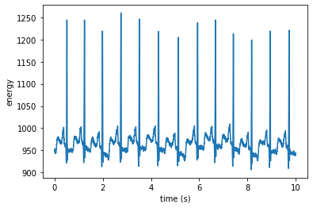

```python
fs = 360 # sampling frequency in Hz, see https://data.mendeley.com/datasets/7dybx7wyfn/3
L = 10 # length of signal in seconds
t = np.linspace(0, L, fs*L)
plt.plot(t, x); plt.xlabel("time (s)"); plt.ylabel("energy");
```

### Signal processing to find heart rate: overall plan

- Find the *peaks*, one per heart-beat, as follows:
  - Apply a threshold to make signal binary, setting $x_t=1$ for any very high value and 0 otherwise
  - Take first differences, ie change from point to point
  - Find points where the first difference is positive, ie change from non-peak to peak
- Calculate how many peaks per unit time.

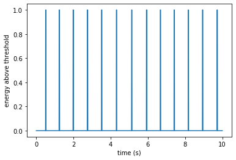

```python
# apply a threshold and plot
xt = x > 1050 # xt = x thresholded
plt.plot(t, xt); plt.xlabel("time (s)"); plt.ylabel("energy above threshold");
```

Next we zoom in. Notice that each peak is *not* a single sample, but several successive ones.

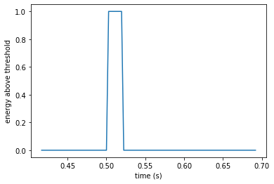

```python
plt.plot(t[150:250], xt[150:250])
plt.xlabel("time (s)"); plt.ylabel("energy above threshold");
```

The first differences will give us the locations where the signal *changes* from 0 to 1 or 1 to 0.

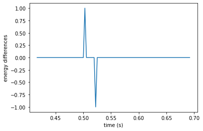

```python
xtd = np.diff(xt, prepend=xt[0]) # xtd = x, thresholded, first differences
plt.plot(t[150:250], xtd[150:250])
plt.xlabel("time (s)"); plt.ylabel("energy differences");
```

We keep only the positive differences: where the original signal goes from "not very high" to "very high"

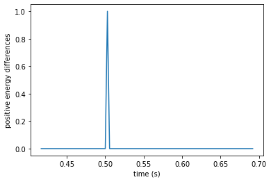

```python
xtdp = xtd > 0 # x, thresholded, first differences, positive
plt.plot(t[150:250], xtdp[150:250])
plt.xlabel("time (s)"); plt.ylabel("positive energy differences");
```

Now each heart beat is represented by a single value 1 surrounded by zeros. The heart rate is just the number of these, divided by total time.

```python
np.sum(xtdp) / L * 60 # heart rate in bpm
```

```
78.0
```

[figure not shown]

# Floating-point numbers

As we know, computer languages can't represent *real* numbers perfectly, because a real number can take on an infinite number of possible values (even in $[0, 1]$), but for any particular number only finite storage is available in the computer.

[figure not shown]

Let's say we are using binary strings of 64 bits to represent real numbers. Consider just a tiny subset of the number line as shown. Let's say it starts at $x$ represented by some bitstring of length 64. There has to be some number which is the next largest, out of all possible bitstrings of length 64. Call that *successor(x)*. Well, in between there are still infinitely many (in fact, uncountably many) other numbers which can't be represented in our 64-bit system! Any of them can only be rounded off to either $x$ or *successor(x)*.

Floating-point, specified by IEEE 754, is the most common scheme for representing real numbers. Single-precision numbers (e.g. `float` in the C language) use 32 bits each, and double-precision (`double`) use 64. In Python all floating-point numbers are double-precision but are just called `float`.

### FP is inexact

Floating-point calculations can be inexact:

```python
2 / 3
```

```
0.6666666666666666
```

By the way, if you want C-style integer division, it is available using `//`:

```python
2 // 3
```

```
0
```

A consequence of this inexactness is that `x == y` is not meaningful for `float` values.

```python
import math
x = math.sqrt(2) ** 2
y = 2.0
x == y
```

```
False
```

Instead we usually use a construction like this:

```python
eps = 10**-8 # epsilon, a small constant which we take as "close enough"
abs(x - y) < eps
```

```
True
```

### FP has upper and lower bounds on magnitude

Some calculations just become too large, and we can get an `OverflowError`:

```python
print("ok:", (10.0**10.0)**10.0)
print("not ok:", 10.0**(10.0**10.0))
```

```
ok: 1e+100
```

```
---------------------------------------------------------------------------
OverflowError                             Traceback (most recent call last)
<ipython-input-5-dc137f252e61> in <module>
      1 print("ok:", (10.0**10.0)**10.0)
----> 2 print("not ok:", 10.0**(10.0**10.0))

OverflowError: (34, 'Result too large')
```

*Machine epsilon* is the academic term for *the smallest magnitude that can be represented* in a floating-point system.

**Exercise**: what is machine epsilon in Python?

```python
# HINT
print(10 ** -10)
print(10 ** -350)
```

### Special numbers

IEEE 754 allows for three special numbers: infinity (`inf`), negative infinity (`-inf`), and *not a number* (`nan`). In principle these can arise through division by zero and similar operations, but in practice Python just throws an error instead:

```python
z = 15 / 0 # would be "inf"
```

```
---------------------------------------------------------------------------
ZeroDivisionError                         Traceback (most recent call last)
<ipython-input-7-af5a1b8b55a3> in <module>
----> 1 z = 15 / 0 # would be "inf"

ZeroDivisionError: division by zero
```

```python
0 / 0 # would be "nan"
```

```
---------------------------------------------------------------------------
ZeroDivisionError                         Traceback (most recent call last)
<ipython-input-8-914a11a0ba07> in <module>
----> 1 0 / 0 # would be "nan"

ZeroDivisionError: division by zero
```

However, we can create these by hand and look at their properties:

```python
inf = float('inf')
neg_inf = -inf
nan = float('nan')
```

```python
inf > 3
```

```
True
```

```python
-inf < inf
```

```
True
```

```python
inf + -inf # don't expect zero, here!
```

```
nan
```

```python
inf + 3
```

```
inf
```

```python
nan < 3
```

```
False
```

### Floating-point errors in Numpy

All of the above is using pure Python. The story becomes slightly different in Numpy. Numpy uses the same floating-point system as pure Python. However, its method of handling errors is different, because in Numpy it is common to process an entire array at once, and an error (e.g. division by zero) might occur only for some elements of the array. So, Numpy allows you to *choose* how errors are handled.

```python
import numpy as np
np.seterr(divide="warn") # see https://docs.scipy.org/doc/numpy/reference/generated/numpy.seterr.html
```

```
{'divide': 'warn', 'over': 'warn', 'under': 'ignore', 'invalid': 'warn'}
```

Here, `divide="warn"` says: if a divide-by-zero error happens, please warn me, but allow the result to be calculated, so I can see it.

```python
x = -1.0
y = np.array([0.0, 1.0, 2.0]) # -1 / 0 -> -inf
x / y
```

```
/Users/jmmcd/anaconda3/lib/python3.7/site-packages/ipykernel_launcher.py:3: RuntimeWarning: divide by zero encountered in true_divide
  This is separate from the ipykernel package so we can avoid doing imports until
```

```
array([-inf, -1. , -0.5])
```

```python
z = np.array([0.0, 1.0, 2.0]) # 0 / 0 -> nan
y / z
```

```
array([nan,  1.,  1.])
```

[figure not shown]

# Numpy: Multidimensional Arrays and Fancy Indexing

### Multidimensional arrays

A 2-dimensional array is like a matrix in maths. We can again make a 2-dimensional array in several ways, e.g. using functions like `np.ones`:

```python
import numpy as np
M = np.ones((3, 3))
print(M)
```

```
[[1. 1. 1.]
 [1. 1. 1.]
 [1. 1. 1.]]
```

Here, we must pass in the *shape* (not just the length). The shape is a tuple of integers.

By the way, we can write `M` on its own in IPython or Jupyter Notebook, and we'll see the output:

```python
M
```

```
array([[1., 1., 1.],
       [1., 1., 1.],
       [1., 1., 1.]])
```

But writing `print(M)` gives a slightly nicer output:

```python
print(M)
```

```
[[1. 1. 1.]
 [1. 1. 1.]
 [1. 1. 1.]]
```

We can also pass in a list of lists to make a two-dimensional array composed of the elements of those lists:

```python
X = [[1.0, 2.0],
     [3.0, 4.0]] # just a list of lists
X = np.array(X)
print(X)
```

```
[[1. 2.]
 [3. 4.]]
```

Again, we can do operations on each element:

```python
X + 10
```

```
array([[11., 12.],
       [13., 14.]])
```

Of course, `X` has not been altered by this:

```python
X
```

```
array([[1., 2.],
       [3., 4.]])
```

We can find out the shape of an array:

```python
X.shape
```

```
(2, 2)
```

### Fancy Indexing

When we studied lists, they were always one-dimensional:

```
L = [4, 5, 6]
```

It requires just one integer to index `L`.

(Ok, we can make *lists of lists*, but by the substitution model we only deal with one dimension at a time: `L = [[4, 5, 6], [7, 8, 9]]` and `L[0][0] == 4`.)

We also saw list *slices*.

As we have seen, we can use indexing and slicing on 1D Numpy arrays, just like with lists. But for multidimensional arrays, we access elements using not a single number but a `tuple`.

```
Operation | Python list | Numpy array
----------|-------------|------------
Index     | L[int]      | a[tuple]
Shape     | len(L)      | a.shape
```

This reflects the move from a single number (length of a list) to a `tuple` (*shape* of an array). We can combine indexing and slicing in that tuple arbitrarily. That is called *fancy indexing*.

```python
print(X)
X[0, 1] # equivalent to X[(0, 1)]
```

```
[[1. 2.]
 [3. 4.]]
```

```
2.0
```

We can also extract a single row:

```python
X[0, :]
```

```
array([1., 2.])
```

Here `0` means "the first row" and `:` means "all columns" -- like writing `[:]` to mean "all elements" in a list slice, which we saw when studying lists. So we get all elements of the first row.

We get a single column in a similar way, and notice that it now "looks like a row".

```python
X[:, 0]
```

```
array([1., 3.])
```

As the logical conclusion of this, we'll see expressions such as `X[:, :]`. You'll say wait, that's not a `tuple`! But it is `:, :` is effectively a `tuple` of slices, where each slice omits both start and end values, so they take on default values.

```python
print(X[:, :])
```

```
[[1. 2.]
 [3. 4.]]
```

```python
print(X[0:X.shape[0], 0:X.shape[1]])
```

```
[[1. 2.]
 [3. 4.]]
```

**Exercise**: what does `X[0]` mean and why?

### Reshaping

If we have, say an array of 10 numbers, we can ask for it to be reshaped as 5$\times$2 or 2$\times$5. The numbers aren't changed -- it's just the *shape* of the table they are presented in:

```python
X = np.array(range(10))
print(X)
```

```
[0 1 2 3 4 5 6 7 8 9]
```

```python
print(X.reshape((5, 2)))
```

```
[[0 1]
 [2 3]
 [4 5]
 [6 7]
 [8 9]]
```

```python
print(X.reshape((2, 5)))
```

```
[[0 1 2 3 4]
 [5 6 7 8 9]]
```

```python
print(X.reshape((10, 1)))
```

```
[[0]
 [1]
 [2]
 [3]
 [4]
 [5]
 [6]
 [7]
 [8]
 [9]]
```

```python
print(X.reshape((1, 10)))
```

```
[[0 1 2 3 4 5 6 7 8 9]]
```

```python
print(X.reshape((10,))) # a tuple of one element: (10,)
```

```
[0 1 2 3 4 5 6 7 8 9]
```

Notice that `X` itself has not been altered:

```python
print(X)
```

```
[0 1 2 3 4 5 6 7 8 9]
```

A related idea is transposing, done using `.T`:

```python
X = np.array([[1.0,  2.0,   3.0],
              [4.0,  5.0,   6.0]])
print(X)
print("") # put a blank line for clarity
print(X.T)
```

```
[[1. 2. 3.]
 [4. 5. 6.]]

[[1. 4.]
 [2. 5.]
 [3. 6.]]
```

**Exercise**: If we have a 2D array and transpose it twice, what happens?

### Matrix multiplication

As we know, many Numpy operations work *per-element*. A binary operation like `*` is straightforward when the two inputs are the same shape:

```python
X = np.array([[1.0,  2.0,   3.0],
              [4.0,  5.0,   6.0]])
Y = np.array([[0.01, 0.1,   1.0],
              [10.0, 100.0, 1000.0]])
print(X * Y)
```

```
[[1.e-02 2.e-01 3.e+00]
 [4.e+01 5.e+02 6.e+03]]
```

That is sometimes called the *element-wise* product or *Hadamard product*. It requires the arrays to have the same size and shape.

### Broadcasting

Numpy also allows multiplication or other functions to work when the two array shapes are *broadcastable*. "the smaller array is 'broadcast' ('reused') across the larger array so that they have compatible shapes". This works as long as corresponding dimensions are *equal*, or one of them is equal to 1, or not present. We line the shapes up "right-aligned":

```
A      (2d array):  2 x 4
B      (1d array):      4
Result (2d array):  2 x 4
```

```python
A = np.array([[1, 2, 3, 4], [5, 6, 7, 8]]); print(A.shape)
B = np.array([10, 11, 12, 13]); print(B.shape)
C = A + B
print(C); print(C.shape)
```

```
(2, 4)
(4,)
[[11 13 15 17]
 [15 17 19 21]]
(2, 4)
```

A contrived example:

```
A      (4d array):  8 x 1 x 6 x 1
B      (3d array):      7 x 1 x 5
Result (4d array):  8 x 7 x 6 x 5
```

```python
A = np.array([[1, 2, 3, 4], [5, 6, 7, 8]]); print(A.shape)
B = np.array([10, 11]); print(B.shape)
C = A + B
```

```
(2, 4)
(2,)
```

```
---------------------------------------------------------------------------
ValueError                                Traceback (most recent call last)
<ipython-input-36-fd5de775c3a0> in <module>
      1 A = np.array([[1, 2, 3, 4], [5, 6, 7, 8]]); print(A.shape)
      2 B = np.array([10, 11]); print(B.shape)
----> 3 C = A + B

ValueError: operands could not be broadcast together with shapes (2,4) (2,)
```

```
A      (2d array):  2 x 4
B      (1d array):      2
Result           :  incompatible
```

```python
A = np.array([[1, 2, 3, 4], [5, 6, 7, 8]]); print(A.shape)
B = np.array([10, 11]).reshape(2, 1); print(B.shape)
C = A + B
print(C)
print(C.shape)
```

```
(2, 4)
(2, 1)
[[11 12 13 14]
 [16 17 18 19]]
(2, 4)
```

```
A      (2d array):  2 x 4
B      (1d array):  2 x 1
Result (2d array):  2 x 4
```

The full rules: https://docs.scipy.org/doc/numpy/user/basics.broadcasting.html

There is also true matrix multiplication, where the two matrices must be of *compatible* shapes (not the same thing). In the following case they are $3\times 2$ and $2\times 2$:

```python
X = np.array([[1.0, 2.0],
              [3.0, 4.0],
              [5.0, 6.0]])
Y = np.array([[1.0, 10.0],
              [100.0, 1000.0]])
print(X.shape)
print(Y.shape)
C = X @ Y
print(C)
print(C.shape)
print(np.dot(X, Y))
```

```
(3, 2)
(2, 2)
[[ 201. 2010.]
 [ 403. 4030.]
 [ 605. 6050.]]
(3, 2)
[[ 201. 2010.]
 [ 403. 4030.]
 [ 605. 6050.]]
```

### Higher-dimensional arrays

So far we have seen 1D and 2D arrays and they are the most common. However, higher dimensions are also common in applications.

A 3D array could arise as a single image: width $\times$ height $\times$ channels.

A typical image has three channels (red, green, blue). The value at location (0, 0, 0) represents the intensity of the red channel at the top-left.

Some .png images have four channels (red, green, blue, alpha), where alpha represents transparency. Greyscale images have just one channel.

A 3D array could also arise by representing a *volume*:

[figure not shown]

https://ipython-books.github.io/13-introducing-the-multidimensional-array-in-numpy-for-fast-array-computations/

- Weather simulation
- 3D grid of cells
- each cell stores temperature in a 100m $\times$ 100m $\times$ 100m cube
- value stored at array location (0, 0, 0): temperature at highest altitude at the south-west corner of the simulation area.

```python
shape = (3, 4, 2)
X = np.random.random(shape); print(X)
```

```
[[[0.07070677 0.84423054]
  [0.08656932 0.55130132]
  [0.99199969 0.13164892]
  [0.7650867  0.66715329]]

 [[0.38941812 0.1506887 ]
  [0.64156382 0.48095295]
  [0.90036734 0.79358824]
  [0.68364997 0.50270988]]

 [[0.43883143 0.47931998]
  [0.45710398 0.24783698]
  [0.32377639 0.89628352]
  [0.00986422 0.39127776]]]
```

It's an unfortunate fact that printing 3D or higher data is ugly on a 2D screen. Numpy just prints out 2D at a time as shown. Think of this as a cube, sliced up. Look carefully at the brackets.

**Exercise**: given `X` as above, which value is stored at `X[0, 2, 1]`?

```python
X[0, 2, 1]
```

```
0.13164891620764096
```

4D and higher are also possible. Colour video footage is effectively 4D: width $\times$ height $\times$ channels $\times$ time.

4D also arises when training neural network models with image data. Each image in the dataset is 3D: width $\times$ height $\times$ channels.

But typical training algorithms process a *batch* of (e.g.) 10 images at a time.

Consider a dataset `X` representing 10,000 square images each of 100$\times$100 pixels, each with 3 channels. Shape would be `(100, 100, 3, 10000)`. Typical code:

```
for i in range(0, 10000, 10): # step=10
    NN.train(X[:, :, :, i:i+10])
```

### Exercises

**Exercise**: what shape would we see with the following data?

- An old, greyscale CCTV camera which shoots 1 frame of 100$\times$100 pixels every second, for 1 minute.

**Exercise**: what shape would we see with the following data?

- A set of 4 temperature sensors, each recording a value once every day for a year.

**Exercise**: Given the data `X`, use fancy indexing to extract sub-arrays on the next slide:

```python
X = np.array([[11, 12, 13, 14],
              [21, 22, 23, 24],
              [31, 32, 33, 34],
              [41, 42, 43, 44]])
print(X)
```

```
[[11 12 13 14]
 [21 22 23 24]
 [31 32 33 34]
 [41 42 43 44]]
```

```
[31 32 33 34] # observe this is 1D

[[31 32 33 34]] # observe this is 2D, of shape (1, 4)

[13 23 33 43]

[[11 12 13 14]
 [21 22 23 24]]

[[22 23]
 [32 33]]
```

### Solutions

- Greyscale CCTV => 1 channel
- 100$\times$100 (width and height)
- 1 per second, 60 seconds => 60
- => 1$\times$100$\times$100$\times$60
- That '1' is superfluous, so: 100$\times$100$\times$60
- 4 temperature sensors: 1 dimension of length 4. Not 4D!
- One value once every day for a year
- => 365$\times$4

```python
X[2, :]
```

```
array([31, 32, 33, 34])
```

```python
X[2:3, :]
```

```
array([[31, 32, 33, 34]])
```

```python
X[:, 2]
```

```
array([13, 23, 33, 43])
```

```python
X[:2, :]
```

```
array([[11, 12, 13, 14],
       [21, 22, 23, 24]])
```

```python
X[1:3, 1:3]
```

```
array([[22, 23],
       [32, 33]])
```

[figure not shown]

# Numpy Example: Fractals

[figure not shown]

(This notebook is partly based on Bauckhage, *NumPy / SciPy Recipes for Image Processing: Creating Fractal Images*, available from https://www.researchgate.net/publication/272679245. The first images are from there. Please refer to that paper for extra background.)

Fractals: self-similarity at different scales

[figure not shown]

The image above is the *Julia set*, a well-known *fractal*. As we may know, a fractal is a mathematical object which has some properties of *self-similarity* at different scales. If we zoom in to the image, we'll see similar objects re-appearing at a smaller scale.

The Julia set is defined as follows. For each point $z_0 = a+bi$ in the complex plane, we apply an iterated map $z_{i+1} = z^2 + c$ many times, where $c = -0.065 + i0.66 \in \mathbb{C}$.

At each step, we look at the *modulus* (size) of the result $z_i$. If after $i$ steps, $|z_i| > 2$ then the point $z_0$ has *escaped* from the circle of radius 2 (and by the way, it will never come back inside). Then we define the Julia value of $z_0$ as the integer $J(z_0) = i$, the *escape time*.

Let's experiment. Try out a few different initial values of `z`, below, and see the escape time.

```python
c = -0.065 + 0.66j # Julia constant: using 'j'
def f(z):
    return z**2 + c # complex arithmetic is built-in
def escape_time(z0, its=20):
    z = z0
    for i in range(its):
        if abs(z) > 2:
            return i
        else:
            z = f(z)
    return its # deem escape time equal to number of iterations, as a default
escape_time(0.4 + -0.1j)
```

```
11
```

Now, some points might take a long time to escape (if ever). We can't keep iterating forever.

We use a maximum of 20 iterations above. Any point $z_0$ which doesn't have an escape time less than 20, we deem to have an escape time of 20, for the purposes of plotting.

By the way, we have claimed that once a point escapes, it will never come back. Let's write code to investigate (it's not a proof, of course).

```python
def test_escape_and_return(z0, its=20):
    z = z0
    for i in range(its):
        if abs(z) > 2:
            print("outside")
            z = f(z)
        else:
            print("inside")
            z = f(z)
    return its # deem escape time equal to number of iterations, as a default
test_escape_and_return(0.4 + 0.5j, 20)
```

```
inside
inside
inside
inside
inside
outside
outside
outside
outside
outside
outside
outside
outside
outside
outside
inside
inside
inside
inside
inside
```

```
20
```

Wait a minute, that's not what we expected! The point escaped, then came back in. **Exercise**: debug this to understand what happened. Hint: print `abs(z)` at each iteration. What is the special case in which the `if`-test becomes False?

If you don't solve this, don't worry -- the rest of notebook still works. I'll post the solution `fractal_escape_and_return.py` in our materials.

So far, we have looked at one point at a time. The beautiful images emerge when we consider all points in a grid, and *plot* their escape times. We'll use Numpy and Matplotlib.

```python
import numpy as np
import matplotlib.pyplot as plt
import matplotlib.cm as cm
```

```python
def JuliaNaive(zmin, zmax, m, n, tmax=256):
    xs = np.linspace(zmin.real, zmax.real, n)
    ys = np.linspace(zmin.imag, zmax.imag, m)
    J = np.zeros((m, n))
    for r, y in enumerate(ys):
        for c, x in enumerate(xs):
            z = x + 1j * y
            J[r, c] = escape_time(z, tmax)
    return J
```

For the Julia set, the following points give suitable boundaries for the grid:

```python
zmin = -1.3 - 1j * 1.3 # ie -1.3 - 1.3i
zmax =  1.3 + 1j * 1.3 # ie  1.3 + 1.3i
```

```python
# warning, this will be slow for large values of m and n
J = JuliaNaive(zmin, zmax, m=30, n=30)
```

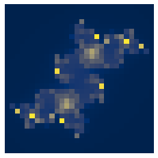

```python
plt.axis('off')
plt.imshow(J, cmap=cm.cividis);
```

This image is a direct representation of a 2D array. Sometimes this kind of plot is called a *heatmap*. We'll see many other types of plot later. **Exercise**: do the dark pixels represent large values, or small ones? Which pixels represent points which are escaping quickly?

As we have seen, implementing the Julia calculations using three nested for-loops is slow. **Exercise:** exactly what three for-loops are we talking about and how are they nested?

### Vectorising our code

Even though we were putting values into a Numpy array, we weren't taking advantage of Numpy vectorisation. In the next version we do so.

```python
c = -0.065 + 0.66j # Julia constant: using 'j'
def f(z):
    return z**2 + c # complex arithmetic is built-in
def Julia(zmin, zmax, m, n, tmax=256):
    xs = np.linspace(zmin.real, zmax.real, n)
    ys = np.linspace(zmin.imag, zmax.imag, m)
    X, Y = np.meshgrid(xs, ys)
    Z = X + 1j * Y
    J = np.ones(Z.shape) * tmax # initialise all points with max escape time
    for t in range(tmax):
        mask = np.abs(Z) <= 2.
        Z[mask] = f(Z[mask])
        J[~mask] -= 1 # decrement escape time of points which have escaped
    return J
```

We have used a handy function, `np.meshgrid`, to give us the x and y coordinates for all pixels. **Exercise**: check the shape and the values stored in `X`, `Y` and `Z`.

- `J` starts with value `tmax` everywhere
- set `mask` where $z$ has not escaped
- decrement `J` wherever $z$ has escaped
- mask runs `f` only where $z$ has not escaped

We have also used a *mask*, that is a Boolean array. It stores the locations where $z$ has not yet escaped. The mask enables us to run `f` only on such locations. We calculate `J` by decrementing the escape time of the *other* points using `~`, the logical `not` operator. The way to think of this is: all points start with escape time `tmax=256`. A point which escapes straight away will be decremented 256 times, so will end up with escape time 0, which is correct.

```python
J = Julia(zmin, zmax, m=1024, n=1024) # much faster!
```

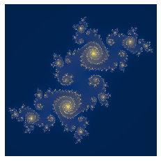

```python
plt.axis('off')
plt.imshow(J, cmap=cm.cividis);
```

**Exercise**: try out different values of $c$ to see what happens. Zoom in by changing `zmin` and `zmax`. Try different colourmaps using `cmap`: see https://matplotlib.org/3.1.0/tutorials/colors/colormaps.html.

The Mandelbrot fractal is another famous one. This time $f(z) = z^2 + z_0$, which is implemented as follows.

```python
def Mandelbrot(zmin, zmax, m, n, tmax=256):
    xs = np.linspace(zmin.real, zmax.real, n)
    ys = np.linspace(zmin.imag, zmax.imag, m)
    X, Y = np.meshgrid(xs, ys)
    Z = X + 1j * Y
    C = np.copy(Z)
    M = np.ones(Z.shape) * tmax
    for t in range(tmax):
        mask = np.abs(Z) <= 2.
        Z[ mask] = Z[mask]**2 + C[mask]
        M[~mask] -= 1.
    return M
```

```python
zmin = -2.3 - 1.5j
zmax =  0.7 + 1.5j
M = Mandelbrot(zmin, zmax, 1024, 1024)
```

[figure not shown]

```python
plt.axis('off')
plt.imshow(M, cmap=cm.jet_r);
```

### Where will we use this?

`meshgrid` is also useful for creating physical simulations, e.g. heat diffusion, water waves, agents in a grid, etc.

### Further reading

- Numberphile on Feigenbaum's constant (related to iterated functions in $\mathbb{R}$ instead of $\mathbb{C}$) and eventually mentions Julia/Mandelbrot fractals: https://www.youtube.com/watch?v=ETrYE4MdoLQ

[figure not shown]

# Numpy: Input/Output

### Reading and writing data with Numpy

To read and write Numpy arrays, we use `np.load()` and `np.save()` like this:

```python
import numpy as np
X = np.random.random((5, 2))
# .npy is a convention for the suffix
np.save("data/mytest.npy", X)
Y = np.load("data/mytest.npy")
print(Y)
```

```
[[0.41738414 0.50075328]
 [0.22414113 0.54842202]
 [0.64288255 0.01291776]
 [0.39759689 0.31183326]
 [0.264635   0.17048049]]
```

The above stores the data in a compressed format, not human-readable. Sometimes it's nice to store in a CSV or similar format instead. `np.savetxt()` and `np.loadtxt()` have lots of options for controlling formatting.

```python
np.savetxt("data/mytest.csv", X,
           delimiter=',', header="a, b",
           fmt="%.3f")
```

```python
# let's look at the file itself:
# if this doesn't work, just open
# data/mytest.csv in a text editor
# the ! syntax allows us to type a
# shell command in IPython.
# 'cat' is not a Python command
!cat "data/mytest.csv"
```

```
# a, b
0.417,0.501
0.224,0.548
0.643,0.013
0.398,0.312
0.265,0.170
```

```python
Y = np.loadtxt("data/mytest.csv",
               delimiter=',', comments="#") # now load it
print(Y)
```

```
[[0.417 0.501]
 [0.224 0.548]
 [0.643 0.013]
 [0.398 0.312]
 [0.265 0.17 ]]
```

**Exercises**: Here are 100 Numpy exercises. Many of these are far too difficult for our purposes here.

https://github.com/rougier/numpy-100

[figure not shown]

# Pandas

- Reading and writing data with Pandas
- Manipulating data with Pandas
- Prerequisites: Numpy

Pandas is a library for data manipulation in Python.

```python
import pandas as pd
```

The central object is the Pandas `DataFrame`, but it is built on top of the Pandas `Series` so we'll look at that first.

A `Series` is like a 1D Numpy `array`:

```python
data = pd.Series([0.25, 0.5, 0.75, 1.0])
data
```

```
0    0.25
1    0.50
2    0.75
3    1.00
dtype: float64
```

Also, the values can be any type (but usually homogeneous):

```python
data = pd.Series(["a", "b", "c", "d"])
data
```

```
0    a
1    b
2    c
3    d
dtype: object
```

The indices can also be anything -- in contrast to a Numpy array -- not just contiguous integers starting from 0.

```python
data = pd.Series([0.25, 0.5, 0.75, 1.0],
                 index=[4, 2, 4/3, 1])
```

```python
data
```

```
4.000000    0.25
2.000000    0.50
1.333333    0.75
1.000000    1.00
dtype: float64
```

The indices don't have to be unique because location is maintained:

```python
data = pd.Series([0.25, 0.5, 0.75, 1.0],
                 index=[4, 2, 2, 1])
data
```

```
4    0.25
2    0.50
2    0.75
1    1.00
dtype: float64
```

The indices will usually be of homogeneous types but it's not strictly required.

### DataFrames

A good way to think of a DataFrame is: it's like a `dict` where the keys are strings (column headers) and the values are Series with a common index.

```python
df = pd.DataFrame({"a": [4, 5, 6, 7],
                   "b": [0.4, 0.5, 0.6, 0.7]},
                  index=[10, 11, 12, 13])
df
```

|  | a | b |
| --- | --- | --- |
| 10 | 4 | 0.4 |
| 11 | 5 | 0.5 |
| 12 | 6 | 0.6 |
| 13 | 7 | 0.7 |

```python
type(df["a"])
```

```
pandas.core.series.Series
```

```python
df["a"].index
```

```
Int64Index([10, 11, 12, 13], dtype='int64')
```

The `id()` function gets the location of an object in memory. So this proves that the entire DataFrame shares a single `index`:

```python
id(df["a"].index) == id(df["b"].index)
```

```
True
```

"NumPy arrays have one dtype for the entire array, while pandas DataFrames have one dtype per column" (from https://pandas.pydata.org/pandas-docs/stable/getting_started/10min.html). So, DataFrames are suitable for "rectangular", spreadsheet-like data with potentially a different data type in each column. So, we'll now see how to create a DataFrame by reading a file in a spreadsheet-like format.

### Reading data with Pandas

The file we're going to use as an example is `data/irish_cities.txt`, available in Blackboard. The columns are separated by tab characters. Also, the file has a *header* which is not part of the data proper.

```python
# ! introduces a shell command
!head data/irish_cities.txt
```

```
# Copied from http://www.tageo.com/index-e-ei-cities-IE.htm -- James McDermott
#Rank	City	Population (2000)	Latitude (DD)	Longitude (DD)
1	Dublin	1027900	53.330	-6.250
2	Cork	195400	51.900	-8.470
3	Limerick	85700	52.670	-8.630
4	Galway	68600	53.280	-9.060
5	Waterford	48300	52.260	-7.130
6	Dundalk	34400	54.020	-6.420
7	Bray	32300	53.210	-6.110
8	Drogheda	28800	53.720	-6.360
```

Pandas `read_csv` makes it easy to deal with all this. We use `sep="\t"` to say the file is *tab*-separated. And we tell it to skip the first row, which is just a comment. It then correctly uses the second row to guess the names for the columns.

```python
# "\t" -> tab-separated
df = pd.read_csv("data/irish_cities.txt",
                 sep="\t",
                 skiprows=1)
```

```python
df.head() # handy for a quick look, nice formatting in Notebook
```

|  | #Rank | City | Population (2000) | Latitude (DD) | Longitude (DD) |
| --- | --- | --- | --- | --- | --- |
| 0 | 1 | Dublin | 1027900 | 53.33 | -6.25 |
| 1 | 2 | Cork | 195400 | 51.90 | -8.47 |
| 2 | 3 | Limerick | 85700 | 52.67 | -8.63 |
| 3 | 4 | Galway | 68600 | 53.28 | -9.06 |
| 4 | 5 | Waterford | 48300 | 52.26 | -7.13 |

Useful arguments for `read_csv`:

- The filename can be a file on disk or a URL.
- `sep="\t"`, `sep=" "`, and `sep=","` tell Pandas what character is used to separate the columns.
- `skiprows=3` means to ignore the first rows entirely.
- `names=["a", "b", "c"]` tells Pandas the names of the columns.
- But if the names of the columns are written at the top of the file, Pandas can figure them out.

Recall that a DataFrame is a bit like a dictionary mapping column headers to columns. We can *alter* the values in the way that you might expect, for example if we want our data to be in millions:

```python
df["Population (2000)"] /= 1000000.0
```

Then we should rename the column to reflect that change, and while we're at it we'll rename a few others.

```python
df = df.rename(columns={"#Rank": "Rank",
                        "Population (2000)": "Population (M)",
                        "Latitude (DD)": "Latitude",
                        "Longitude (DD)": "Longitude"})
df.head()
```

|  | Rank | City | Population (M) | Latitude | Longitude |
| --- | --- | --- | --- | --- | --- |
| 0 | 1 | Dublin | 1.0279 | 53.33 | -6.25 |
| 1 | 2 | Cork | 0.1954 | 51.90 | -8.47 |
| 2 | 3 | Limerick | 0.0857 | 52.67 | -8.63 |
| 3 | 4 | Galway | 0.0686 | 53.28 | -9.06 |
| 4 | 5 | Waterford | 0.0483 | 52.26 | -7.13 |

Now, we can access the columns and treat them like Numpy arrays.

```python
df["Population (M)"].sum()
```

```
2.0366000000000004
```

Aggregation functions like `mean()` on the whole DataFrame work across all numerical arguments -- which might not be meaningful, for all data:

```python
df.mean()
```

```
Rank              25.000000
Population (M)     0.041563
Latitude          53.042449
Longitude         -7.391224
dtype: float64
```

```python
df.describe() # handy, general description
```

|  | Rank | Population (M) | Latitude | Longitude |
| --- | --- | --- | --- | --- |
| count | 49.00000 | 49.000000 | 49.000000 | 49.000000 |
| mean | 25.00000 | 0.041563 | 53.042449 | -7.391224 |
| std | 14.28869 | 0.146841 | 0.692864 | 1.083562 |
| min | 1.00000 | 0.006700 | 51.810000 | -9.720000 |
| 25% | 13.00000 | 0.008800 | 52.500000 | -8.300000 |
| 50% | 25.00000 | 0.013100 | 53.140000 | -7.160000 |
| 75% | 37.00000 | 0.019500 | 53.450000 | -6.480000 |
| max | 49.00000 | 1.027900 | 54.940000 | -6.050000 |

We can take subsets of the data, e.g.:

```python
df[df["Population (M)"] > 0.05]
```

|  | Rank | City | Population (M) | Latitude | Longitude |
| --- | --- | --- | --- | --- | --- |
| 0 | 1 | Dublin | 1.0279 | 53.33 | -6.25 |
| 1 | 2 | Cork | 0.1954 | 51.90 | -8.47 |
| 2 | 3 | Limerick | 0.0857 | 52.67 | -8.63 |
| 3 | 4 | Galway | 0.0686 | 53.28 | -9.06 |

This works because `df["Population (M)"]` returns a Boolean array, which is then used to select a subset of `df`.

We can use Boolean operations for more powerful subsetting. Notice that we use a *single* `&` symbol here for `and`, and the round brackets are needed.

```python
df[(df["Population (M)"] > 0.05) &
   (df["Longitude"] < -8)]
```

|  | Rank | City | Population (M) | Latitude | Longitude |
| --- | --- | --- | --- | --- | --- |
| 1 | 2 | Cork | 0.1954 | 51.90 | -8.47 |
| 2 | 3 | Limerick | 0.0857 | 52.67 | -8.63 |
| 3 | 4 | Galway | 0.0686 | 53.28 | -9.06 |

### Creating a DataFrame from scratch

If we are generating data somehow, we can build up the DataFrame from scratch. For example, we might want to test how fast a `sort()` function is for different input sizes, and store the results in a DataFrame.

```python
import numpy as np
import time
```

```python
ns = [i * 10**6 for i in range(1, 11)] # sizes
reps = 5 # how many repetitions
cols = {"n": ns} # dict {name: column}
for rep in range(reps):
    col = []
    for n in ns:
        L = np.random.random(n) # create a list
        # start time after generating the list...
        start = time.time()
        L.sort() # ... this is the workload
        end = time.time()
        elapsed = end - start
        col.append(elapsed)
    cols["run%d" % rep] = col # new name: column
```

```python
cols.keys()
```

```
dict_keys(['n', 'run0', 'run1', 'run2', 'run3', 'run4'])
```

```python
cols["n"]
```

```
[1000000,
 2000000,
 3000000,
 4000000,
 5000000,
 6000000,
 7000000,
 8000000,
 9000000,
 10000000]
```

```python
cols["run0"]
```

```
[0.09924602508544922,
 0.197066068649292,
 0.30280303955078125,
 0.44548678398132324,
 0.5835180282592773,
 0.7712948322296143,
 1.5356290340423584,
 0.981870174407959,
 1.2411689758300781,
 1.3824279308319092]
```

```python
df = pd.DataFrame(cols)
df.head(n=10)
```

|  | n | run0 | run1 | run2 | run3 | run4 |
| --- | --- | --- | --- | --- | --- | --- |
| 0 | 1000000 | 0.099246 | 0.109996 | 0.101855 | 0.100453 | 0.114092 |
| 1 | 2000000 | 0.197066 | 0.194505 | 0.203326 | 0.193344 | 0.256533 |
| 2 | 3000000 | 0.302803 | 0.300889 | 0.316597 | 0.365341 | 0.385361 |
| 3 | 4000000 | 0.445487 | 0.531404 | 0.416161 | 0.488978 | 0.485014 |
| 4 | 5000000 | 0.583518 | 0.580889 | 0.531411 | 0.632583 | 0.543272 |
| 5 | 6000000 | 0.771295 | 0.738762 | 0.645505 | 0.745687 | 0.652128 |
| 6 | 7000000 | 1.535629 | 0.771055 | 0.766083 | 0.792273 | 0.745622 |
| 7 | 8000000 | 0.981870 | 0.942297 | 0.883724 | 0.865534 | 0.942807 |
| 8 | 9000000 | 1.241169 | 1.078446 | 1.010357 | 0.999629 | 1.302248 |
| 9 | 10000000 | 1.382428 | 1.189598 | 1.164332 | 1.292596 | 1.355849 |

Suppose we want to take the mean and standard deviation across runs, and add them as new columns.

- Create a new column in `df` using `df.mean`
- Create a new column in `df` using `df.std`

```python
# add columns to df
# .mean(axis=1) means take the average across columns
# (axis=0 would mean across rows)
# but df[["run0", "run1", etc]] gives a DataFrame
# with a subset of columns
df["mean"] = df[["run0", "run1", "run2",
                 "run3", "run4"]].mean(axis=1)
df["sd"] = df[["run0", "run1", "run2",
               "run3", "run4"]].std(axis=1)
```

```python
df.head()
```

|  | n | run0 | run1 | run2 | run3 | run4 | mean | sd |
| --- | --- | --- | --- | --- | --- | --- | --- | --- |
| 0 | 1000000 | 0.099246 | 0.109996 | 0.101855 | 0.100453 | 0.114092 | 0.105128 | 0.006543 |
| 1 | 2000000 | 0.197066 | 0.194505 | 0.203326 | 0.193344 | 0.256533 | 0.208955 | 0.026876 |
| 2 | 3000000 | 0.302803 | 0.300889 | 0.316597 | 0.365341 | 0.385361 | 0.334198 | 0.038706 |
| 3 | 4000000 | 0.445487 | 0.531404 | 0.416161 | 0.488978 | 0.485014 | 0.473409 | 0.044152 |
| 4 | 5000000 | 0.583518 | 0.580889 | 0.531411 | 0.632583 | 0.543272 | 0.574335 | 0.039773 |

Let's save to disk, and check what it looks like on disk.

```python
df.to_csv("data/sort_times.csv")
```

```python
!cat data/sort_times.csv
```

[output not shown]

We have seen `read_csv` and `to_csv`. Pandas also allows reading/writing/interacting with Excel, SQL, HDF5 (for big data), and lots more.

### `groupby`

Pandas can do all sorts of data joins, pivot tables and more -- things that are familiar to power users of SQL, Excel, and other data manipulation tools.

Let's start with this diagram from Vanderplas [Data Science Handbook](https://jakevdp.github.io/PythonDataScienceHandbook/03.08-aggregation-and-grouping.html#GroupBy:-Split,-Apply,-Combine). It shows a common scenario: we choose a key column (not necessarily the index) and split the table up (conceptually) by the values in it. Then we apply an aggregation across each split, then recombine.

The result of the final combine is a new object a bit like a DataFrame. This is similar to carrying out a pivot table in Excel. We accomplish all this in a `groupby` command in Pandas. First we'll get the Irish cities data again.

[figure not shown]

From [Vanderplas Data Science Handbook](https://jakevdp.github.io/PythonDataScienceHandbook/03.08-aggregation-and-grouping.html)

```python
df = pd.read_csv("data/irish_cities.txt", sep="\t", skiprows=1)
df["Population (2000)"] /= 1000000.0
df = df.rename(columns={"#Rank": "Rank",
                        "Population (2000)": "Population (M)",
                        "Latitude (DD)": "Latitude",
                        "Longitude (DD)": "Longitude"})
df.head()
```

|  | Rank | City | Population (M) | Latitude | Longitude |
| --- | --- | --- | --- | --- | --- |
| 0 | 1 | Dublin | 1.0279 | 53.33 | -6.25 |
| 1 | 2 | Cork | 0.1954 | 51.90 | -8.47 |
| 2 | 3 | Limerick | 0.0857 | 52.67 | -8.63 |
| 3 | 4 | Galway | 0.0686 | 53.28 | -9.06 |
| 4 | 5 | Waterford | 0.0483 | 52.26 | -7.13 |

`groupby` works naturally with discrete keys, so we'll make one by rounding off the *longitude*.

```python
df["Longitude (round)"] = df["Longitude"].astype('int')
```

```python
df.head()
```

|  | Rank | City | Population (M) | Latitude | Longitude | Longitude (round) |
| --- | --- | --- | --- | --- | --- | --- |
| 0 | 1 | Dublin | 1.0279 | 53.33 | -6.25 | -6 |
| 1 | 2 | Cork | 0.1954 | 51.90 | -8.47 | -8 |
| 2 | 3 | Limerick | 0.0857 | 52.67 | -8.63 | -8 |
| 3 | 4 | Galway | 0.0686 | 53.28 | -9.06 | -9 |
| 4 | 5 | Waterford | 0.0483 | 52.26 | -7.13 | -7 |

We can now use `groupby` to split the data by (rounded) longitude, calculate the mean on each split, then recombine to a single table.

```python
gb = df.groupby("Longitude (round)").mean()
gb
```

| Longitude (round) | Rank | Population (M) | Latitude | Longitude |
| --- | --- | --- | --- | --- |
| -9 | 21.600000 | 0.024220 | 53.320000 | -9.352000 |
| -8 | 25.000000 | 0.040278 | 52.460000 | -8.556667 |
| -7 | 27.416667 | 0.015300 | 53.013333 | -7.529167 |
| -6 | 24.478261 | 0.059539 | 53.225217 | -6.436957 |

This `groupby` result is an object similar to a DataFrame, which we could manipulate further.

There's a lot more in `groupby` and in Pandas in general for this type of data manipulation, but we won't go any further.

### Plotting in Pandas

Pandas has some built-in plotting abilities, e.g.:

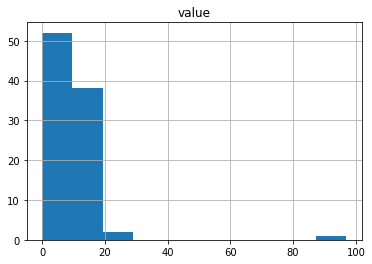

```python
# read data on sugar content of cereals, sampled from a
# supermarket in Michigan in 2004.
# copied from http://www.math.hope.edu/swanson/data/cereal.txt
# (and then edited)
d = pd.read_csv("data/cereals.txt",
                names=["value"])
d.hist();
```

https://kanoki.org/2019/09/16/dataframe-visualization-with-pandas-plot/ - a quick rundown on plotting in Pandas. Usually, I prefer to use Matplotlib or Seaborn, which we'll cover in the next notebooks.

[figure not shown]

# Plotting with Matplotlib

Data visualisation is an important step in almost every data analysis. In Python there are many plotting libraries, which all accept Numpy arrays as input data. The main plotting library is called Matplotlib, and we will later see another built on top of it, called Seaborn.

We can plot data directly inside the Jupyter Notebook or inside the IPython console in Spyder. We import and also use a Jupyter magic command (starts with `%`) to enable the inline plotting.

```python
import numpy as np
import pandas as pd
import matplotlib.pyplot as plt
# this line tells the notebook to show plots "inline"
%matplotlib inline
```

Let's say we want to plot the formula $y = 1.7x + 12.3 \sin(3x)$ for all values of $x$ from 0 to 10. Numpy and Matplotlib make it easy as follows.

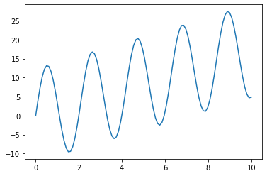

```python
x = np.linspace(0, 10, 100)
y = 1.7 * x + 12.3 * np.sin(3 * x)
plt.plot(x, y);
```

**Exercise**: why did we put a semi-colon at the end of the last line?

**Exercise**: Plot the formula $0.2 * (0.7^x)$ for $x \in [0, 20]$.

Of course, we can change the plotting style:

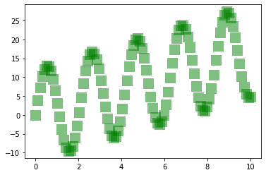

```python
# 's' -> squares instead of lines
# alpha -> transparency
# markersize -> size
# markeredgewidth=0 -> remove borders on markers
plt.plot(x, y, "s", color="g", alpha=0.5,
         markersize=15, markeredgewidth=0);
```

A "stem plot":

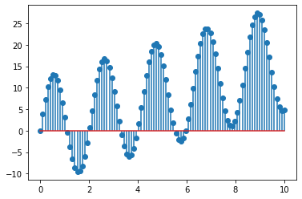

```python
plt.stem(x, y, use_line_collection=True);
```

We can plot multiple lines on the same plot against the same $x$-axis, using different styles for each, and add a legend:

```python
x = np.linspace(0, 10, 100)
y = 1.7 * x + 12.3 * np.sin(3 * x)
z = 5 + 2 * x - 0.5 * x**2
```

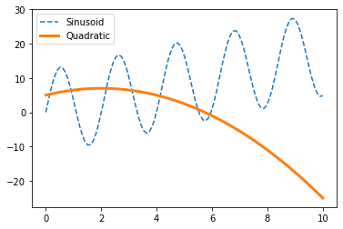

```python
plt.plot(x, y, linestyle="--", label="Sinusoid")
plt.plot(x, z, linewidth=3, label="Quadratic")
plt.legend();
```

And we should *always* label our axes.

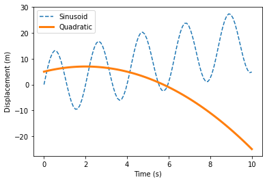

```python
plt.plot(x, y, linestyle="--", label="Sinusoid")
plt.plot(x, z, linewidth=3, label="Quadratic")
plt.legend()
plt.xlabel("Time (s)")
plt.ylabel("Displacement (m)");
```

### Histograms

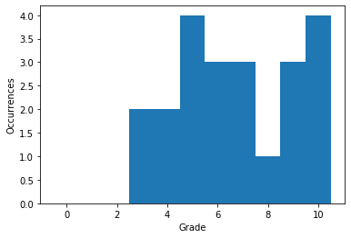

```python
grades = np.loadtxt("data/grades.csv")
# use range to force integer alignment
plt.hist(grades, range=(-0.5, 10.5), bins=11)
plt.xlabel("Grade")
plt.ylabel("Occurrences");
```

### Scatter plots

To understand the relationship between a pair of variables, we often start with scatterplots and correlation values. We'll take an example extracted from a dataset with efficiency of cars (miles per gallon). We'll use `np.corrcoef` and then `plt.scatter`.

```python
x = np.loadtxt("data/mpg_extract.csv", delimiter=",")
x.shape # 398 cars, 2 variables: year and efficiency
```

```
(398, 2)
```

```python
r = np.corrcoef(x[:, 0], x[:, 1])
r # show correlation matrix
```

```
array([[1.        , 0.57926713],
       [0.57926713, 1.        ]])
```

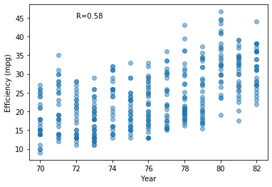

```python
plt.scatter(x[:, 0], x[:, 1], alpha=0.5)
plt.xlabel("Year")
plt.ylabel("Efficiency (mpg)")
plt.text(72, 45, "R=%.2f" % r[0, 1]);
```

### Using Pandas data

If we have a Pandas DataFrame, we can use it directly instead of extracting columns. Compare:

`plt.plot("xvar", "yvar", data=df)`

`plt.plot(df["xvar"], df["yvar"])`

**Example**: recall the data file `data/sort_times.csv` which we created in the notebook about Pandas. The first column was the independent variable $n$ (the size of the array being sorted), and the other columns were multiple observations of the dependent variable $y$, i.e. the *elapsed time* in seconds. We have already calculated the mean and standard deviation across observations, and stored them as new colums. Now, using `plt.errorbar`: plot the mean of $y$ against $n$, with errorbars given by the standard deviation of $y$.

```python
# index_col=0 tells Pandas that the first column is an index
# not a data column
df = pd.read_csv("data/sort_times.csv", index_col=0)
df.head() # take a look
```

|  | n | run0 | run1 | run2 | run3 | run4 | mean | sd |
| --- | --- | --- | --- | --- | --- | --- | --- | --- |
| 0 | 1000000 | 0.099246 | 0.109996 | 0.101855 | 0.100453 | 0.114092 | 0.105128 | 0.006543 |
| 1 | 2000000 | 0.197066 | 0.194505 | 0.203326 | 0.193344 | 0.256533 | 0.208955 | 0.026876 |
| 2 | 3000000 | 0.302803 | 0.300889 | 0.316597 | 0.365341 | 0.385361 | 0.334198 | 0.038706 |
| 3 | 4000000 | 0.445487 | 0.531404 | 0.416161 | 0.488978 | 0.485014 | 0.473409 | 0.044152 |
| 4 | 5000000 | 0.583518 | 0.580889 | 0.531411 | 0.632583 | 0.543272 | 0.574335 | 0.039773 |

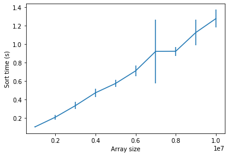

```python
# note use of df column names and 'yerr'
plt.errorbar(x="n", y="mean", yerr="sd", data=df)
plt.xlabel("Array size")
plt.ylabel("Sort time (s)");
```

### Inline plots versus saving

Sometimes we want to show a plot in a notebook; sometimes we want to save to disk. The following code will save the plot to a `png` file. You can also use `pdf`, `svg`, and other formats. As we may know, `png` is a bitmap format suitable for the web; `pdf` is a vector format suitable for documents.

```python
plt.savefig("data/sort_times.png")
plt.close()
```

### Warning

There are at least two different ways of using `matplotlib`:

- Pyplot stateful interface (what we've been using)
- Pyplot object-oriented interface

We've been using the Pyplot stateful interface. A command like `plt.xlabel` changes the `x` label of whatever figure `plt` is currently working on.

Another way of working is the Pyplot object-oriented interface, which is a bit more powerful than the interface we've been using and confusing to mix. Usually plotting starts with `fig, ax = plt.subplots()`. See [discussion here](https://jakevdp.github.io/PythonDataScienceHandbook/04.00-introduction-to-matplotlib.html#Two-Interfaces-for-the-Price-of-One).

If we see some documentation online which involves `pylab`, keep away!

### Further reading

The Matplotlib website https://matplotlib.org/ holds docs, and the gallery works as a cookbook: https://matplotlib.org/gallery/index.html.

Vanderplas has another very nice book with a section on Matplotlib: https://jakevdp.github.io/PythonDataScienceHandbook/04.00-introduction-to-matplotlib.html

Some general advice on programming plots:

- Try designing it on paper before programming
- Try making very simple plots in an interactive setting (Jupyter Notebook or Spyder) and then iterating to refine it
- Don't try to remember all the parameters and syntax -- just know how to look for plots e.g. in the galleries.

### Exercises

**Exercise**: generate a pseudo-map of the Republic of Ireland by plotting the longitude and latitude of `data/irish_cities.txt`. Plot the city population as size. Hint: extract the population column to an array `size` and manipulate it to give good sizes for the city markers.

### Solutions

```python
!head -n 15 data/mile_run.txt # show the first 15 lines
```

```
# The following gives the winning time, in seconds, for the mile run.
# The year in which occured, the name of the runner, and the runner's
# nationality are also given.

# Copied from http://www.math.hope.edu/swanson/data/mile_run.txt and
# edited format -- James McDermott.

Year,Athlete,Nationality,Time(seconds)
1913,John Paul Jones,USA,254.4
1915,Norman Taber,USA,252.6
1923,Paavo Nurmi,Finland,250.4
1931,Jules Ladoumegue,France,249.2
1933,Jack Lovelock,New Zealand,247.6
1934,Glenn Cunningham,USA,246.8
1937,Sydney Wooderson,UK,246.4
```

```python
df = pd.read_csv("data/mile_run.txt", delimiter=",", skiprows=7)
df.head()
```

|  | Year | Athlete | Nationality | Time(seconds) |
| --- | --- | --- | --- | --- |
| 0 | 1913 | John Paul Jones | USA | 254.4 |
| 1 | 1915 | Norman Taber | USA | 252.6 |
| 2 | 1923 | Paavo Nurmi | Finland | 250.4 |
| 3 | 1931 | Jules Ladoumegue | France | 249.2 |
| 4 | 1933 | Jack Lovelock | New Zealand | 247.6 |

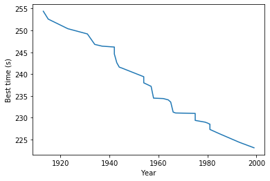

```python
plt.plot("Year", "Time(seconds)", data=df)
plt.xlabel("Year")
plt.ylabel("Best time (s)");
```

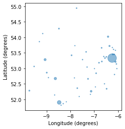

```python
import pandas as pd
import matplotlib.pyplot as plt
df = pd.read_csv("data/irish_cities.txt", sep="\t", skiprows=1)
df = df.rename(columns={"#Rank": "Rank",
                        "Population (2000)": "Population (M)",
                        "Latitude (DD)": "Latitude",
                        "Longitude (DD)": "Longitude"})
df["Population (M)"] /= 10**6
# set the size of the circles
size = df["Population (M)"] * 300
# the "aspect" is the shape -- 1.0m would mean square.
# we use aspect=1.3 because latitude/longitude
# are only "square" at the equator
plt.axes().set_aspect(1.3)
# alpha sets the circles slightly transparent
# so you can see overlaps
plt.xlabel("Longitude (degrees)")
plt.ylabel("Latitude (degrees)")
plt.scatter("Longitude", "Latitude", s=size, data=df, alpha=0.5);
```

[figure not shown]

# Plotting with Seaborn

### Seaborn

"Seaborn is a library for making statistical graphics in Python. It is built on top of matplotlib and closely integrated with pandas data structures." -- from Seaborn docs.

- Default styles are nicer
- Some "higher-level" plots are builtin which would take a lot of work in Matplotlib
- Better integration with Pandas

(But Matplotlib has caught up in some ways)

```python
import numpy as np
import pandas as pd
import seaborn as sns
# this line tells the notebook to show plots
# "inline". seaborn calls matplotlib behind
# the scenes, so this line still just says
# %matplotlib, not %seaborn!
%matplotlib inline
```

In Seaborn, as in Matplotlib, we can pass a Pandas DataFrame as `data`, and choose which columns to plot with kwargs `x` and `y`:

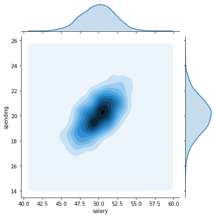

```python
df = np.random.multivariate_normal(
    [50, 20], [[5, 2], [2, 2]], size=2000) # some fake data
df = pd.DataFrame(df,
                  columns=["salary", "spending"])
# kde = kernel density estimation
sns.jointplot(x="salary", y="spending",
              data=df, kind="kde");
```

Here's an example with real-world data -- the Boston Housing dataset, which has house prices ("MEDV", in thousands of dollars) and several variables which may be predictive of prices.

```python
df = pd.read_csv("data/boston.csv", index_col=0)
df.head()
```

|  | CRIM | ZN | INDUS | CHAS | NOX | RM | AGE | DIS | RAD | TAX | PTRATIO | B | LSTAT | MEDV |
| --- | --- | --- | --- | --- | --- | --- | --- | --- | --- | --- | --- | --- | --- | --- |
| 0 | 0.00632 | 18.0 | 2.31 | 0.0 | 0.538 | 6.575 | 65.2 | 4.0900 | 1.0 | 296.0 | 15.3 | 396.90 | 4.98 | 24.0 |
| 1 | 0.02731 | 0.0 | 7.07 | 0.0 | 0.469 | 6.421 | 78.9 | 4.9671 | 2.0 | 242.0 | 17.8 | 396.90 | 9.14 | 21.6 |
| 2 | 0.02729 | 0.0 | 7.07 | 0.0 | 0.469 | 7.185 | 61.1 | 4.9671 | 2.0 | 242.0 | 17.8 | 392.83 | 4.03 | 34.7 |
| 3 | 0.03237 | 0.0 | 2.18 | 0.0 | 0.458 | 6.998 | 45.8 | 6.0622 | 3.0 | 222.0 | 18.7 | 394.63 | 2.94 | 33.4 |
| 4 | 0.06905 | 0.0 | 2.18 | 0.0 | 0.458 | 7.147 | 54.2 | 6.0622 | 3.0 | 222.0 | 18.7 | 396.90 | 5.33 | 36.2 |

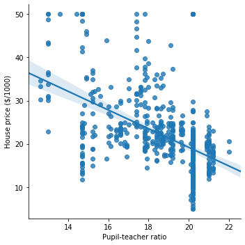

```python
sns.lmplot(x="PTRATIO", y="MEDV", data=df
          ).set_axis_labels(
    "Pupil-teacher ratio",
    "House price ($/1000)");
```

`lmplot` (linear model plot) gives us:

- data as a scatter plot
- a linear regression model, i.e. a trendline (linear regression is studied in other modules)
- a shaded confidence interval on the linear model

One more example, this time the Iris dataset which has measurements from a few species of Iris (a type of flower).

```python
# some example datasets are built-in
iris = sns.load_dataset("iris")
iris.head()
```

|  | sepal_length | sepal_width | petal_length | petal_width | species |
| --- | --- | --- | --- | --- | --- |
| 0 | 5.1 | 3.5 | 1.4 | 0.2 | setosa |
| 1 | 4.9 | 3.0 | 1.4 | 0.2 | setosa |
| 2 | 4.7 | 3.2 | 1.3 | 0.2 | setosa |
| 3 | 4.6 | 3.1 | 1.5 | 0.2 | setosa |
| 4 | 5.0 | 3.6 | 1.4 | 0.2 | setosa |

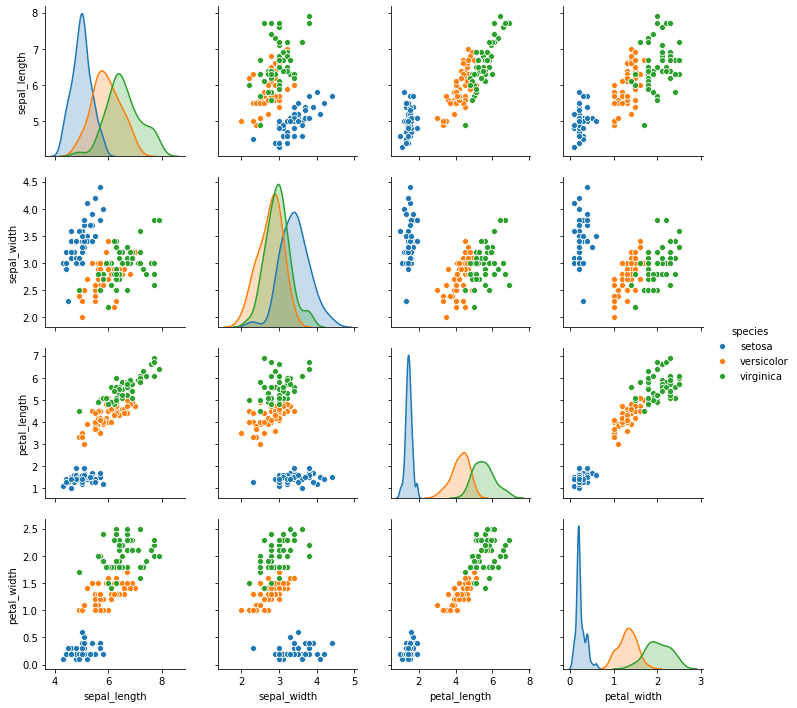

```python
sns.pairplot(data=iris, hue="species");
```

As we can see, `sns.pairplot` takes in a whole Pandas DataFrame (multiple variables), and gives us:

- a scatterplot on each pair of variables (numeric variables only)
- a distribution for each individual variable
- optionally use another variable to discriminate data by colour (`hue`)

For more, scroll through these three pages which showcase the main functionality.

https://seaborn.pydata.org/introduction.html

https://seaborn.pydata.org/examples/index.html

https://jakevdp.github.io/PythonDataScienceHandbook/04.14-visualization-with-seaborn.html

By the way, there is another module in data visualisation which goes much farther than we will here:

- CT5100 Data Visualisation
- CT5136 Data Visualisation - Online

**Exercise**: scroll through the Seaborn examples https://seaborn.pydata.org/examples/index.html. Choose any example. Copy its code into your notebook and run it. Then try to achieve the same type of plot on any other dataset.

[figure not shown]

# Computational Complexity

This notebook will start by reviewing the main idea of computational complexity, and then try to make it practical in the Python context. We will try to explain a lot of things that are usually left unsaid.

Computational efficiency is important!

Computer scientists realised long ago that the efficiency of an algorithm isn't really well-measured by measuring the "wall clock time" it takes to execute.

We can reduce runtime by buying a faster computer, faster disk, or a better network connection, or rewriting (the same algorithm) in a different language, but that doesn't change the inherent complexity of the algorithm.

Instead, what is important is **how quickly the runtime increases as the size of the input increases (as input gets arbitrarily large)**.

A typical scenario: we run our algorithm with a small input file. It takes 10s to read in the data and 10s to process it. Then we run it on a larger input file. It takes 10m to read in the data, and 3 weeks to process it. The real issue here is the growth in processing from 10s to 3 weeks. We want to ignore the time spent reading the data.

### Assumptions

- A program consists of idealised "instructions"
- There may be several types of instructions, e.g. multiplying two numbers, or checking for integer equality
- Some may be slower than others, but only by a **constant factor**;
- If one instruction is slower than another by a factor that **depends on program input size**, it is not an instruction -- we have to see it as composed of multiple instructions.

With these assumptions, we can write the runtime as the number of instructions -- a formula in $n$, the size of the input.

- To calculate the row-sum (sum of each row, as a vector) of a square matrix ($n$ rows and $n$ columns):

```python
def row_sum(M):
    R = []
    for L in M:
        R.append(sum(L))
    return R
```

Notice that `sum(L)` is not an instruction, because its runtime depends on the size of the `row_sum` input `M`. Instead, `sum` is composed of multiple instructions.

(But `sum([4, 5, 6])` does not depend on the size of `M`, so it counts as 1.)

### Worst-case

In computational complexity, if the number of instructions could vary (for fixed input size), we usually consider the **worst-case**. This takes care of situations where the algorithm can exit early for a special case or an error: we don't want to count those when measuring complexity.

(There are situations where we'll consider average-case as well, see later.)

- E.g. to check that a given element exists in a list of length $n$:

```python
def element_exists(L, y):
    for x in L:
        if x == y: return True
    return False
```

We have to look at all $n$ elements (worst-case). We'll have to look up $n$ items and make $n$ comparisons, so we'll execute $2n$ instructions.

### Asymptotic runtime

"Asymptotic behaviour" means something like "behaviour for arbitrarily large values". In computational complexity, we only care about the number of instructions executed for large $n$.

How large?

"Arbitrarily large". For small $n$, the number is probably dominated by setup or reading input, and anyway for small $n$ the program will be fast anyway, so we just don't care about runtime in the first place.

So the runtime is the number of instructions -- a formula in $n$. Now, we are going to argue that in that formula, for large $n$, only the **fastest-growing term** in $n$ matters.

Let's look at the growth of a few simple terms.

```python
import math
import matplotlib.pyplot as plt
%matplotlib inline
```

```python
plt.rcParams["figure.figsize"] = (8, 5)
plt.rcParams.update({'font.size': 14})
```

```python
ns = range(2, 21)
growths = {
    "constant": lambda n: 1,
    "logarithmic": lambda n: math.log(n),
    "linear": lambda n: n,
    "log-linear": lambda n: n * math.log(n),
    "quadratic": lambda n: n ** 2
}
```

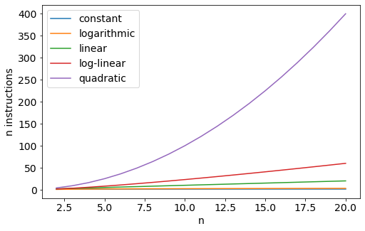

```python
for growth in growths:
    plt.plot(ns, [growths[growth](n) for n in ns],
             label=growth)
plt.legend(); plt.xlabel("n");
plt.ylabel("n instructions");
```

What we see is a huge discrepancy between terms even for small $n$.

It doesn't matter if we execute 1000$\times$ more instructions in one algorithm than another. Consider `1000*linear`, below.

It also doesn't matter if one algorithm does a lot of extra setup that another doesn't. Consider `100000+linear`, below.

The `quadratic` function is still far worse than both even for this small $n=2000$.

```python
ns = range(2, 2001)
growths = {
    "linear": lambda n: n,
    "100000+linear": lambda n: n + 100000,
    "1000*linear": lambda n: n * 1000,
    "quadratic": lambda n: n ** 2
}
```

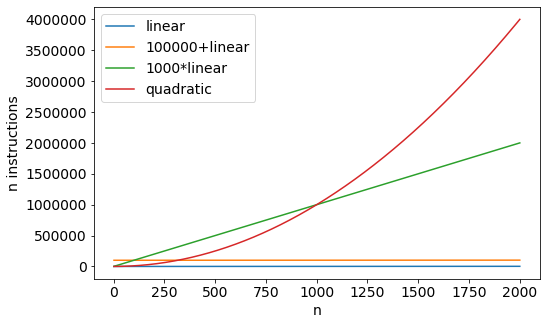

```python
for growth in growths:
    plt.plot(ns, [growths[growth](n) for n in ns],
             label=growth)
plt.legend(); plt.xlabel("n");
plt.ylabel("n instructions");
```

It also doesn't matter if one type of instruction is (say) 1000$\times$ slower than another: again, consider `1000*linear` above. This justifies our (surprising) assumption that we can treat all instructions as equal.

And, e.g., `sum(range(1000))` counts as **one instruction**.

Therefore, for large $n$, the **number of instructions** of the **fastest-growing term** in $n$ is effectively **proportional** to runtime.

### "Big O" notation

We **ignore** all slow-growing terms. The "Big O" notation ("the order of complexity") does just this:

- Write the total number of instructions as a function of $n$, e.g. $10n^2 + 23n\log(n) + 1000000$
- Drop all but the fastest-growing term and drop its coefficient, and write in "big O" notation: $O(n^2)$.

**Exercise**: consider again the `element_exists(L, x)` function. We saw that its *worst-case* complexity is $O(n)$. What is its *average-case* complexity?

**Answer**: the average-case complexity is still $O(n)$. On average we will have to compare $n/2$ elements, so we'll do $n/2$ lookups and $n/2$ comparisons, giving $O(n)$.

There are a few common "Big O" values. Here they are from slowest- to fastest-growing.

- constant, $O(1)$
- logarithmic, $O(\log(n))$
- linear, $O(n)$
- log-linear aka quasi-linear, $O(n\log(n))$
- quadratic, $O(n^2)$

### Examples

- We already argued that to check a particular item exists in a list of length $n$, we need $2n$ instructions. That is linear, $O(n)$.
- Calculating the row-sum a square matrix of size $n$ is quadratic, $O(n^2)$.
- Sorting a list of length $n$ takes $O(n\log(n))$.

This is a classic example. It doesn't matter what algorithm you use, it can't be better than $O(n\log(n))$. (There are algorithms which are much worse, e.g. **bubble sort**.) Thus, it is justified to talk about the complexity of the **problem**, not just the complexity of the **algorithm**.

### Rules of thumb

- Every for-loop multiplies by a factor of $n$, e.g. this is $O(n^3)$:

```
for i in range(n):
    for j in range(n):
        for k in range(n):
            # do something
```

Reading input data can usually be ignored. We usually just assume that reading an input file is $O(n)$, i.e. linear in the number of lines or file size, and so we ignore it. We know that processing won't be sub-linear, so the time spent reading data won't exceed it, so it can be ignored.

People say things like "comparison-based sorting algorithms like Merge sort take only Big O $O(n \log(n))$ and so you can sort just about any amount of data in a feasible time" (https://www.gwern.net/Complexity-vs-AI). Why does $O(n \log(n))$ imply that it is feasible?

It's because $O(n\log(n))$ is only a little slower than $O(n)$ itself. We already assume that we can read the data in feasible time, otherwise the question of sorting it would not arise. Reading it is $O(n)$. So if we can read it into RAM, we can sort it. If our RAM is not big enough, the sorting algorithm will be bottlenecked by *thrashing*.

Sometimes we might have multiple inputs, e.g. two arrays of sizes $n$ and $m$, or a 2D array of size $n\times m$. In these cases we might need $O()$ expressions in both $n$ and $m$. Alternatively we might just (conservatively) take $n$ to be the larger of $n$ and $m$.

The most important difference in practice is between linear and log-linear algorithms and quadratic.

In a linear algorithm, "you took some input and did something simple to each element" (Accidentally Quadratic, http://accidentallyquadratic.tumblr.com/post/113840433022/why-accidentally-quadratic).

A quadratic algorithm can occur if we need to traverse the whole input once for every element of the input.

$O(n\log n)$ can occur if we take something like that and improve it with a tree structure, because the cost of traversing a tree from root to leaf is often $O(\log n)$.

Another place $O(n\log n)$ occurs is in sorting algorithms, and one "reason" why it occurs there is that some algorithms work recursively, and so induce an implicit binary tree structure of function calls.

Exponential and factorial algorithms seem to occur mostly as algorithms that our common sense would probably tell us not to write in the first place.

### Situations not governed by computational complexity

Suppose we are running a webserver. Every request that comes in is approximately the same, small, size. We don't care about asymptotic complexity. We **do** care about the setup time and the coefficients!

We only care about computational complexity if we're going to have large inputs. Someone once criticised me for using an $O(n^2)$ algorithm instead of $O(n)$ in a situation where we knew $n < 7$. You might say "well $6 < 6^2$, so it will be faster".

But remember that for small $n$ the assumptions break down: we can't ignore the coefficient or the "slow-growing" terms. E.g. for $n < 7$, $n^2 < 20 + 3n$.

### Complexity in Python data structures

We have been discussing idealised instructions. How do they correspond to Python source code?

Well, it turns out that many of the operations of the Python compound datatypes (`list`, `set`, `dict`, `tuple`) take time which depends on the size of the object (e.g. `list.find` takes time proportional to the length of the `list`).

Therefore, we can't regard these as idealised instructions! Instead we have to see them as composed of multiple instructions and calculate how many of *those* there are.

### Time complexity of basic Python operations

The basic Python data types (list, tuple, set, dict, and a couple of others) offer various operations, with various time complexities. They make different trade-offs between time and memory usage in different common cases and worst cases. Sometimes the right choice can make a huge difference to our efficiency.

Sources:

- https://www.ics.uci.edu/~pattis/ICS-33/lectures/complexitypython.txt
- https://wiki.python.org/moin/TimeComplexity
- Downey, *Think Python*, Appendix B
- Downey, *Think Complexity*, Chapter 3.

### Lists

```
8   [ ][ ][ ][ ][ ][ ][ ][ ]
                          ^
```

A Python `list` is represented internally as an **array** (contiguous cells in memory). Many operations involve iterating over the items: $O(n)$. However, it stores a pointer to the end (so `append` is constant-time) and remembers its length (so no need to iterate for `len`).

A `list` is also fast for changes at the end, but slow for changes near the beginning: e.g. deleting the first item means that all other items have to "move".

- $O(1)$: append, get and set item (`[]`), `len`
- $O(n)$: insert item, delete item, iterate over, `min`, `x in L`

### Tuple

Similar to list, for the operations that are allowed.

### Dictionaries

Recall that a **hash function** is the crucial ingredient in implementing `dict`s. (In fact, also in `set`s.) A hash function maps an object to an integer, uniformly distributed over some wide range.

Recall that Python offers a general hash function `hash`, and some objects are **not hashable**.

```python
print(hash(2))
print(hash('abc'))
print(hash([5, 6, 7]))
```

```
2
6999911826370106077
```

```
---------------------------------------------------------------------------
TypeError                                 Traceback (most recent call last)
<ipython-input-14-131228568170> in <module>
      1 print(hash(2))
      2 print(hash('abc'))
----> 3 print(hash([5, 6, 7]))

TypeError: unhashable type: 'list'
```

### Implementing a dictionary from scratch

(Warning: this is for illustration/intuition: the internal implementation is much more complicated)

Suppose we have a language with lists, but no dictionaries. To make a dictionary, we make a **list** `L` of some small fixed size, e.g. 10, and fill with non-values:

```
L = [(None, None), (None, None), ... (None, None)]
```

To add a key `k` with value `v`, we calculate a "bucket" or "pigeonhole" which tells us where to write that key-value:

```
i = hash(k) % 10
```

and we set

```
L[i] = (k, v)
```

To later retrieve the value for key `k`, we calculate `i` and get `L[i]`: its first element is `k` and second is `v`.

### Dictionary performance

- Calculating `hash` and looking up `list` element `i` are both $O(1)$ operations!
  - (Constant with respect to the number of elements "filled" in `L`.)
- However, a dict uses extra memory in return for this speedup:
  - It makes a list of size 10, even when the dict is empty!
- For many situations, this trade-off is well worth it.

### Hash collisions

But sometimes two keys `k1`, `k2` could get the same `i` -- called a *hash collision*

[output not shown]

So we need a bit more logic to avoid over-writing an existing key-value, or returning the wrong value, or reporting that an key is present when it's not.

Because each element of the list contains the key, we can use an approach which checks it. One idea is called *linear probing*:

When we are about to add a key-value pair at location `L[i]`, and there's already a *different* key there, just go to `L[i+1]` and see if there is an empty space there (and repeat as needed). (And the same thing when retrieving.)

This works as long as the list is sparsely populated, so there are few collisions and most linear probes end quickly.

But eventually, if we keep adding key-values, we'll find a lot of collisions, so we'll spend forever linear probing, and get bad performance. Even worse, when the dictionary gets full, there's no space for new elements!

At that point we have to **re-hash**:

- Make a new, much larger list `L`;
- Re-calculate all the indices (`% len(L)`);
- Copy each old element to its new location in the new list.

That will take a long time, so our **worst-case time** for item addition is $O(n)$. But it happens **rarely**.

### Amortized analysis

- Typically, adding an entry to a `dict` takes $O(1)$;
- Very rarely, it takes $O(n)$;
- On average across many additions to a single `dict`, performance is practically constant-time.

Since in any higher-level algorithm using `dict` we can expect to be adding to it many times, we are justified in using the `dict` average-case instead of worst-case. This is called **amortized analysis**.

### Dictionary performance

Thus, we have $O(1)$ average-case performance for common dict operations:

- $O(1)$: `x in d`, add item, retrieve item, delete item, `len`
- $O(n)$: iterate over items

### Sets

We could implement a set as a dictionary with keys and dummy values!

That is, for a set element `x` we would use the key-value pair `(x, x)`.

In early Python, that's how `set` was implemented. (It's optimized now.)

Result: the same $O(1)$ performance for common operations:

- $O(1)$: `x in s`, add item, delete item, `len`
- $O(n)$: iterate over items

**Exercise**: which is faster: `x in L` or `x in S` or `x in d`? (`list`, `set`, or `dict`)

**Solution**: `x in S` and `x in d` are both $O(1)$ while `x in L` is $O(n)$.

"The performance of dictionaries is one of the minor miracles of computer science." -- Downey, *Think Complexity*.

### Double-ended queue

A list is fast for changes at the end, but slow for changes near the beginning. If modelling a true queue we would probably want to optimise for `append` (add at the end) and `popleft` (remove from the front).

But Python provides a double-ended queue (`deque`) which makes both ends fast.

- $O(1)$: append, appendleft, pop, popleft, `len`
- $O(n)$: get, set or remove element in the middle

### Implications

Many of our algorithms depend for run-time on careful choice of data structure

- E.g. breadth-first search needs queue behaviour ("first-in, first-out"). We can emulate this behaviour using a list (append new item at one end, copy item and delete at the other), but this will be slow: a deque is much better.

### Example: Complexity of ML algorithms

- What is the complexity of logistic regression?
- The **training** and the **prediction** algorithms are totally different!
- What is $n$?
- For **prediction**, we take in a vector $x$. We predict the probability $p = 1/(1+e^{-wx})$.
- The only possible $n$ is the number variables, i.e. `len(x)`. The calculation takes just $O(n)$.
- For **training**, we have an input dataset with $n$ variables, and $m$ examples, and (suppose we use gradient descent) we iterate for some number of iterations $s$. It should be clear that our complexity will be **linear** in $m$ and in $n$ and in $s$, so it is $O(nms)$. Depending on what we are trying to achieve, we could just call that e.g. $O(m)$ (treating $n$ and $s$ as fixed).

Caveat: we'll set $s$ in a way that may depend a bit on the difficulty of the problem!

[figure not shown]

# High-Performance Computing

The purpose of this notebook is to provide the basic terminology and concepts of high-end/high-performance computing. If you already know what these are, you can skip it!

- Threads versus processes
- Distributed versus parallel computing
- GPUs
- Taskfarming
- Profilers

### Python and HPC

Python is slow, but it's still used for (some) HPC! Why?

- Numpy can move many inner loops to C or Fortran
- "Just-in-time" compilation with Numba, Cython, PyPy, etc.
- Deep learning uses GPUs, Python uses GPU libraries
- Python is slower than C only by a (multiplicative) constant. Getting the right algorithm remains more important.

### GPUs

[figure not shown]

Aa **graphics processing unit** is a specialised processor for graphics, especially video games. A GPU is specialised for processing large numerical matrices. Many AI and numerical computing problems run very effectively on GPUs!

[figure not shown]

- Deep learning is always on GPUs, except for toy problems
- Cryptocurrency [:-(](https://www.sciencedaily.com/releases/2019/06/190613104533.htm)
- Weather simulations, nuclear simulations, and more.

### Distributed versus parallel computing

Parallel computing: running multiple things at once on a single machine (especially with multiple CPUs on a single machine)

Distributed computing: running one thing across multiple machines, usually with message-passing between them.

### Parallel computing

[figure not shown]

https://www.explainthatstuff.com/how-supercomputers-work.html

### Parallel computing with threads and processes

Threads and processes are two similar concepts. They both involve multiple parts of a program running in parallel (on a single machine).

- Every program, when it runs, becomes a **process**
- A program may **fork** to become multiple processes
- A program may also create multiple **threads**

Threads are more "lightweight" (easier/quicker to start and stop threads than processes).

If we have multiple CPUs, then multiple processes or multiple threads can take advantage of that.

Even if we have a single CPU, multiple processes or threads can be useful. (They don't really run in **parallel**, but the OS gives that illusion by interleaving their work, and it can still help a lot!)

### Examples

- Any program with a GUI will have at least a back-end process and a GUI process or thread. Even when the back-end process is busy processing, the GUI remains responsive.
- A web server typically launches a new thread for every incoming request.
- Some optimisation algorithms can run multiple processes or threads, e.g. all running in parallel, to take advantage of multiple CPUs, e.g.~`GridSearchCV` has a parameter `n_jobs`.

Communication between threads and/or processes is a complex topic and causes many bugs :-/

### Using multiple cores -- the hard way

Take our program, and rewrite it to use multiple processes and/or threads with communication between them. When it runs, the OS will put each process/thread on separate cores in a fairly smart/adaptive way. We'll get a speedup, but probably sublinear :-(

### Using multiple cores -- the easy way

If we need to run our program **multiple times** and we have **multiple cores** (and if each run won't use up too much RAM), then don't rewrite the program. Just run it multiple times at once. E.g. if we have 4 cores, open up 4 terminals and type `python myprog.py` in each one. We'll probably get a 4x speedup :-)

This is a bit too **manual** for large-scale tasks (e.g. many runs on multiple machines). **Taskfarming** takes this to a logical conclusion: we put our commands into a file and hand it to a specialised taskfarming program. It decides how many to run in parallel, and takes care of starting the next one whenever a task finishes (to ensure CPU utilisation) etc.

It can even use multiple machines if available.

In the next notebook/video we'll see how this is used on ICHEC.

### Distributed computing

[figure not shown]

In distributed computing, we have multiple machines running a single job, so usually they need to communicate during the job. This is outside our scope.

### Understanding performance in terms of bottlenecks

When a program is too slow, there are many possible reasons:

- Slow CPU
- Not enough RAM causes the machine to move data from RAM to disk and back often ("thrashing")
- Wrong algorithm (e.g. "accidentally quadratic")

And many possible solutions:

- Buy a bigger computer or a GPU
- Use parallel and/or distributed computing
- Find a better algorithm.

[figure not shown]

https://www.kissclipart.com/manufacturing-bottleneck-clipart-bottleneck-busine-0xtdag/

A **bottleneck** model is useful for thinking about performance. Usually when a program is slow, there's one main reason why it's slow, e.g. just one function or one inner loop. That's the only place where an optimisation effort can yield any improvements.

Before trying to optimise a function, we should find out **which functions** are using most of the time in our program!

That's the job of the **profiler**. A profiler is a tool that runs your program and tells you where it spends most of its time. It gives a report like this, telling us how often each function is called and the total time spent in each function.

```
197 function calls (192 primitive calls) in 0.002 seconds

Ordered by: standard name

ncalls  tottime  percall  cumtime  percall filename:lineno(function)
     1    0.000    0.000    0.001    0.001 <string>:1(<module>)
     1    0.000    0.000    0.001    0.001 re.py:212(compile)
     1    0.000    0.000    0.001    0.001 re.py:268(_compile)
     1    0.000    0.000    0.000    0.000 sre_compile.py:172(_compile_charset)
     1    0.000    0.000    0.000    0.000 sre_compile.py:201(_optimize_charset)
     4    0.000    0.000    0.000    0.000 sre_compile.py:25(_identityfunction)
   3/1    0.000    0.000    0.000    0.000 sre_compile.py:33(_compile)
```

Python has a built-in profiler: https://docs.python.org/3/library/profile.html

Sophisticated understanding of algorithms and engineering and budget trade-offs might be needed! You could pay a developer to make your algorithm use less RAM, but it might be cheaper to just buy a load of extra RAM. You could implement a Hadoop solution, but it might be better to just [learn to use basic tools properly](https://adamdrake.com/command-line-tools-can-be-235x-faster-than-your-hadoop-cluster.html).

We have barely scratched the surface here, but you can see more in **Tools and Techniques for Large-Scale Data Analytics** in Semester 2.

For now, we'll assume that our program is reasonably well-optimised, and we want to run it multiple times with different hyperparameters, so a possible solution is to use **taskfarming** on a large compute server with multiple CPUs (maybe even multiple machines) and/or machines with GPUs. That's what we'll study next.

[figure not shown]

# ICHEC

ICHEC is the Irish Centre for High-End Computing, a department of NUI Galway hosted in the IT Building. The server farm is in Waterford and some staff are in Dublin.

### The **Kay** supercomputer

- 336 nodes each of 2x 20-core 2.4GHz and 192 GiB of RAM
- 16 GPU nodes, as above plus 2x NVIDIA Tesla V100
- Some more nodes with bigger processors/more memory
- Login nodes and other service nodes.
- https://www.ichec.ie/about/infrastructure/kay
- https://www.ichec.ie/academic/national-hpc/documentation

### Condominium access versus Class-C access

- Each Irish institution has "condominium" access to ICHEC, including MSc students. https://www.ichec.ie/academic/condonium-service
- Alternatively, researchers can apply for "Class-C projects", and then add other researchers to the project to give them access.

### Condominium access

The MScAI (full-time) will use this. To get access:

- Register on https://register.ichec.ie/register
- Fill in the Word form (in Blackboard) and send to Noreen Goggin noreen.goggin@nuigalway.ie

See `ichec.pdf` for full details.

### Class-C access

The MScAI (part-time) will use this. To get access:

- Register on https://register.ichec.ie/register
- Send you ICHEC username, student number, and programme name to the Programme Director.
- Go to https://register.ichec.ie/login/ and login, and find the project `ngcom018c`, click `Apply` and `Confirm`.

See `ichec.pdf` for full details.

### `ssh`

`ssh` is a command for logging-in to a remote node. When you have an ICHEC account, you can run this on your laptop:

```
$ ssh my_username@kay.ichec.ie
```

You'll be asked for your password and you'll end up at a Linux prompt on a `kay` login node. The login node is for managing your files and submitting batch jobs. Do not directly **run** any large jobs there!

Access is from within the NUI Galway network only!

Later on, for convenience, you can set up access from home/elsewhere also by generating an SSH keypair: https://www.ichec.ie/academic/national-hpc/documentation/ssh-keys

### Python on ICHEC

Lots of people are using Python for jobs on ICHEC.

https://www.ichec.ie/academic/national-hpc-service/software/python-conda

### Virtual environments

It's recommend to use a **virtual environment** to manage your Python/Anaconda installation. A `venv` is just a collection of software installed with Anaconda.

You can create multiple virtual environments and activate the one you want. One advantage is you might have one project that uses Tensorflow 1 and another that uses Tensorflow 2, and you want to be able to run both projects at different times. You can create a `venv` for each project with the right packages installed and just switch between them.

### Setting up your environment

You can do this on a login node:

```
# tell kay we will use Anaconda
module load conda/2
# create a new venv
conda create --name my_env
# activate it
conda activate my_env
# install the stuff we need
conda install tensorflow-gpu networkx scikit-learn
# for completeness: exit the virtual environment
conda deactivate
```

A `venv` is just a collection of software installed with Anaconda. It doesn't include the contents of your home directory. So, the next step is to make and/or copy your work directories to `kay`, e.g. on a login node:

```
mkdir work
```

You'll need to be able to navigate a Unix filesystem, e.g.:

- `mkdir # make directory`
- `mv # move/rename`
- `cp # copy`
- `cd # change directory`
- `ls # list directory`

### `scp`

`scp` is a command for copying files to a remote computer. When you have an ICHEC account, you can run this on your laptop (notice `-r` is for "recursive copy"):

```
$ scp -r my_project_directory my_username@kay.ichec.ie:/ichec/home/users/my_username/work/
```

### NFS

The contents of your home directory on the login node (which we started to create above) are synced back and forth to any compute node on `kay` your jobs might run on via `NFS`, the network filesystem.

### Interactive testing with `srun`

Then you can request a node for eg 30m interactive testing. This is just for testing/prototyping, not for large runs.

Run this from the login node:

```
srun -p DevQ -N 1 -A nuig02 -t 0:30:00
```

If one is available, you will be delivered to a compute node on DevQ. Then:

```
module load conda/2
conda info --envs
source activate my_env
cd work/my_project_directory
python my_prog.py
```

After whatever length of time you requested (e.g. 30m above), your session will expire and you'll be logged out from that node.

### Batch mode

Above, we used `kay` interactively (typing commands at the shell), but **batch mode** is the common way to run large jobs. "Batch mode" is the opposite of "interactive mode".

That sounds like a downgrade! But HPC systems provide batch mode because:

- jobs are long-running (hours or days), so no benefit to being interactive;
- the system can balance resource allocation for fairness and throughput.

### SLURM

SLURM is a workload manager. It is the mechanism we use to submit batch jobs for execution on `kay`.

[figure not shown]

### Queues

When you submit a job for batch execution, you submit it to a **queue**. ICHEC has several distinct queues with different types of nodes, including:

| Name | Node type | Max nodes | Max walltime | Purpose |
| --- | --- | --- | --- | --- |
| DevQ | Cluster | 4 | 1 hour | Prototyping |
| ProdQ | Cluster | 40 | 72 hours | Large jobs |
| GpuQ | GPU | 4 | 48 hours | GPU jobs |

### Submitting jobs with `sbatch`

To specify a job, we first create a special shell script with the `.sh` suffix, e.g. `work/my_project_directory/my_batch_job.sh`:

```
#!/bin/sh

# request 1 node for 1 hour on DevQ queue
#SBATCH --time=1:00:00
#SBATCH --nodes=1
#SBATCH -p DevQ
#SBATCH -A nuig02
#SBATCH --mail-user=my.email@nuigalway.ie
#SBATCH --mail-type=BEGIN,END

module load taskfarm
module load conda/2
# module load cuda/10 # uncomment for GPU
source activate my_env

cd $SLURM_SUBMIT_DIR
python my_prog.py
```

The first line is a standard way of telling the operating system that it is a shell script to be run by `/bin/sh`, a standard shell.

`sbatch` is the Unix command which submits a job to a queue. We run it like this on a login node:

```
cd work/my_project_directory
sbatch my_batch_job.sh
```

### Taskfarming

The above procedure only makes sense if `my_prog.py` is a very large job that requires a whole node to itself!

An easier way to use supercomputer facilities is to run many runs in parallel, one per core. Suppose our program `my_prog.py` has a hyperparameter `n` which takes on values 0-9, and for each we want to run 100 repetitions with 100 random seeds. We write our program to accept arguments `my_prog.py <n> <seed>`.

Then we can just put these commands into a file named e.g. `tasks.sh`:

```
# each line is one command
python my_prog.py 0 0
python my_prog.py 0 1
python my_prog.py 0 2
...
python my_prog.py 9 99
```

Then, instead of `python my_prog.py` at the bottom of `my_batch_job.sh`, we'll put a `taskfarm` command:

```
taskfarm tasks.sh
```

It will take each line of `tasks.sh` as a task. It will start tasks, usually one per core, and when they finish it will start new ones, until the whole file is finished.

### After submitting

- You can check on your queued jobs: `squeue -u my_username`
- You should receive an email when the job **starts**.
  - It might contain error messages. To debug, check your account name and check that your tasks run ok interactively.
- When your job finishes, you should receive another email.

### GPU on `kay`

Ensure that your `venv` includes (e.g.) `tensorflow-gpu` (it should as we installed it earlier). Then request a GPU node for interactive testing:

```
srun -p GpuQ -N 1 -A nuig02 -t 0:30:00
```

If one is available, you will be delivered to a compute node with GPU. Then run these:

```
module load cuda/10.0
module load conda/2
conda info --envs # what envs exist?
source activate my_env
# test that GPU support is working - you should see lots of messages
# including "name: Tesla V100-PCIE-16GB"
python -c 'import tensorflow as tf; tf.test.gpu_device_name()'
```

Then make sure to include the line `module load cuda/10.0` in your `my_batch_job.sh` file.

In the **Deep Learning** module (in Semester 2 for full-time students, in Year 2 Semester 2 for part-time), you'll have opportunities to use deep neural network libraries such as Tensorflow or PyTorch on GPU.

[figure not shown]

# Scikit-Learn: Introduction

[figure not shown]

Scikit-Learn provides a wide variety of machine learning algorithms and utilities with a fairly uniform interface.

A useful resource is the Vanderplas *Python Data Science Handbook* https://jakevdp.github.io/PythonDataScienceHandbook/ and we will draw on this, referring to it as *PDSH*.

We'll start with **supervised learning**.

Vanderplas (PDSH) describes the core workflow for supervised learning in Scikit-Learn as: "import/instantiate/fit/predict"

I would add another step:

- import
- instantiate
- fit
- **evaluate**
- predict

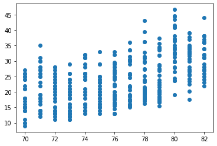

```python
import numpy as np
import matplotlib.pyplot as plt
d = np.loadtxt("data/mpg_extract.csv", delimiter=",",
               skiprows=1)
d[:5] # year, mpg
plt.scatter(d[:, 0], d[:, 1]);
```

- Independent variables: array of shape `(n_samples, n_variables)`
- (even if `n_variables == 1`)
- Our dependent variable is typically of shape `(n_samples,)`.

```python
X = d[:, 0:1]
y = d[:, 1]
X.shape, y.shape
```

```
((398, 1), (398,))
```

### Make a train-test split

```python
from sklearn.model_selection import train_test_split
X_train, X_test, y_train, y_test = train_test_split(X, y)
```

- Notice the order of the result -- very hard to remember!
- Notice a convention for uppercase `X` (a vector of variables) and lowercase `y` (a single variable)

### Import

```python
from sklearn.linear_model import LinearRegression
```

### Instantiate

```python
lr = LinearRegression()
```

### Fit

```python
lr.fit(X_train, y_train)
```

```
LinearRegression(copy_X=True, fit_intercept=True, n_jobs=None, normalize=False)
```

### Evaluate

```python
lr.score(X_test, y_test)
```

```
0.38796002887551734
```

The result is an $R^2$ value, i.e. a coefficient of determination. Higher is better.

### Predict

For an unknown `X`:

```python
X_query = np.array([[83.]])
fX_query = lr.predict(X_query)
fX_query
```

```
array([31.30689899])
```

Notice the result is of shape `(1,)`.

### Understanding the model

Look at the fitted parameters $a$ and $b_i$ (for $i \in $ `(0, n_vars-1)`).

```python
a = lr.intercept_
B = lr.coef_
a, B
```

```
(-63.18180027796002, array([1.13841806]))
```

### Visualise

We'll look at our test data, newly-fitted model, and the query point.

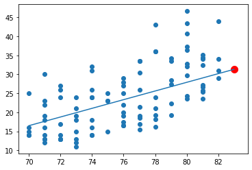

```python
X_grid = np.linspace(70, 83, 14)
fX_grid = a + B * X_grid
plt.scatter(X_test, y_test)
plt.plot(X_grid, fX_grid)
plt.scatter(X_query, fX_query, s=100, c="red");
```

Observe that this is *extrapolation*, not *interpolation*, i.e. we are trying to predict for a point which is "outside" the observed `X` (not just unseen).

### Summary

- get data
- train-test split
- import
- instantiate
- fit on training data
- look at model parameters
- evaluate on test data
- visualise
- **query on new data**

### Pandas instead of Numpy

We can pass in a Pandas `DataFrame` as `X`

```python
import pandas as pd
df = pd.read_csv("data/mpg_extract.csv",
                 names=["year", "mpg"], skiprows=1)
X = df[["year"]]
y = df[["mpg"]]
X_train, X_test, y_train, y_test = train_test_split(X, y)
lr.fit(X_train, y_train)
lr.predict([[85]]) # result is a Numpy array, not Pandas
```

```
array([[33.97513394]])
```

**Exercises**

1. Replace LinearRegression here with `DecisionTreeRegressor`. Is $R^2$ better?
2. Read in the dataset `data/titanic.csv`. Set `X` to be the first three columns, and `y` to be the `survived` column. The goal is to predict `survived`. Use `sklearn.linear_model.LogisticRegression`, and follow the steps above for a train-test split and fit.

**Exercises**

1. Evaluate on the test set using `score`. What does the score value mean in classification? Which is better, high or low? Look it up if needed.
2. Predict whether the following (fictional) passenger would survive: Jack, age 20, travelling in 3rd class. Use `predict_proba` to predict also the *probability* of surviving.

**Solutions**

```python
from sklearn.tree import DecisionTreeRegressor
dt = DecisionTreeRegressor()
dt.fit(X_train, y_train)
dt.score(X_test, y_test) # R^2
```

```
0.3610267988691396
```

```python
df = pd.read_csv("data/titanic.csv")
df.head()
```

|  | pclass | sex_f0m1 | age | survived |
| --- | --- | --- | --- | --- |
| 0 | 3 | 1 | 22.0 | 0 |
| 1 | 1 | 0 | 38.0 | 1 |
| 2 | 3 | 0 | 26.0 | 1 |
| 3 | 1 | 0 | 35.0 | 1 |
| 4 | 3 | 1 | 35.0 | 0 |

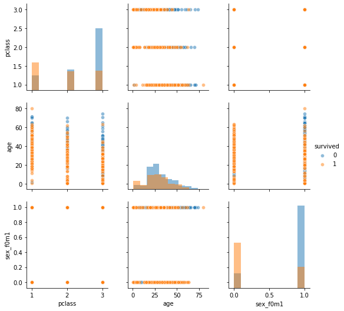

```python
import seaborn as sns
# the pairplot is not perfect for discrete vars
# but still useful. several extra args to improve appearance
sns.pairplot(df, vars=["pclass", "age", "sex_f0m1"],
             diag_kind="hist",
             hue="survived",
             plot_kws={"alpha": 0.5},
             diag_kws={"alpha": 0.5}
            );
```

```python
X = df[["pclass", "age", "sex_f0m1"]]
y = df["survived"]
X_train, X_test, y_train, y_test = train_test_split(X, y)
```

```python
from sklearn.linear_model import LogisticRegression
logr = LogisticRegression()
```

```python
logr.fit(X_train, y_train, solver="lbfgs")
```

[output not shown]

```python
logr.score(X_test, y_test)
```

```
0.8100558659217877
```

`help(logr.score)` -> percentage accuracy, so higher is better, so 81% is pretty good.

```python
jack = np.array([[3, 20, 1]])
logr.predict(jack)
```

```
array([0])
```

```python
logr.predict_proba(jack)
```

```
array([[0.85169886, 0.14830114]])
```

This means there is a 14.8% probability of surviving :-(

[figure not shown]